# Analysis of Activity from Monitoring Devices

#### Are there differences in activity patterns between weekdays and weekends?

For this part the `weekdays()`) function may be of some help here. Use the dataset with the filled-in missing values for this part.

1. Create a new factor variable in the dataset with two levels – “weekday” and “weekend” indicating whether a given date is a weekday or weekend day.

```r
# get the weekday for the given data
data.wo.na$weekday <- weekdays(data.wo.na$date, abbreviate = TRUE)
# create a factor variable 'weekday' / 'weekend'
data.wo.na$datetype <- ifelse(data.wo.na$weekday %in% c("Sat", "Sun"), "weekend",
    "weekday")
data.wo.na$datetype <- as.factor(data.wo.na$datetype)
# display structure of the data
str(data.wo.na)
```

```
## 'data.frame':    17568 obs. of  5 variables:
##  $ steps   : int  NA NA NA NA NA NA NA NA NA NA ...
##  $ date    : Date, format: "2012-10-01" "2012-10-01" ...
##  $ interval: int  0 5 10 15 20 25 30 35 40 45 ...
##  $ weekday : chr  "Mon" "Mon" "Mon" "Mon" ...
##  $ datetype: Factor w/ 2 levels "weekday","weekend": 1 1 1 1 1 1 1 1 1 1 ...
```

1. Make a panel plot containing a time series plot (i.e. `type = "l"`) ) of the 5-minute interval (x-axis) and the average number of steps taken, averaged across all weekday days or weekend days (y-axis).

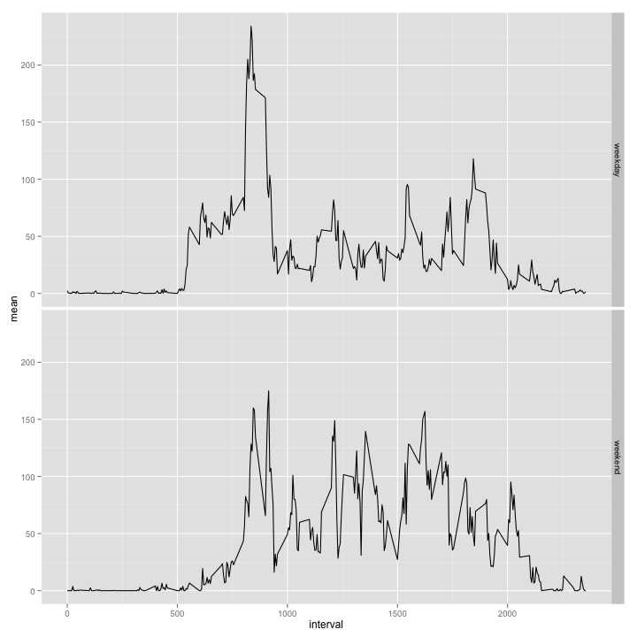

```r
# average the number of steps by interval for all days
agg.data <- ddply(data.wo.na, .(interval, datetype), summarize, mean = mean(steps,
    na.rm = TRUE))
# plot average number of steps by interval and weekday/weekend
ggplot(agg.data, aes(x = interval, y = mean)) + geom_line(type = "l") + facet_grid(datetype ~
    .)
```

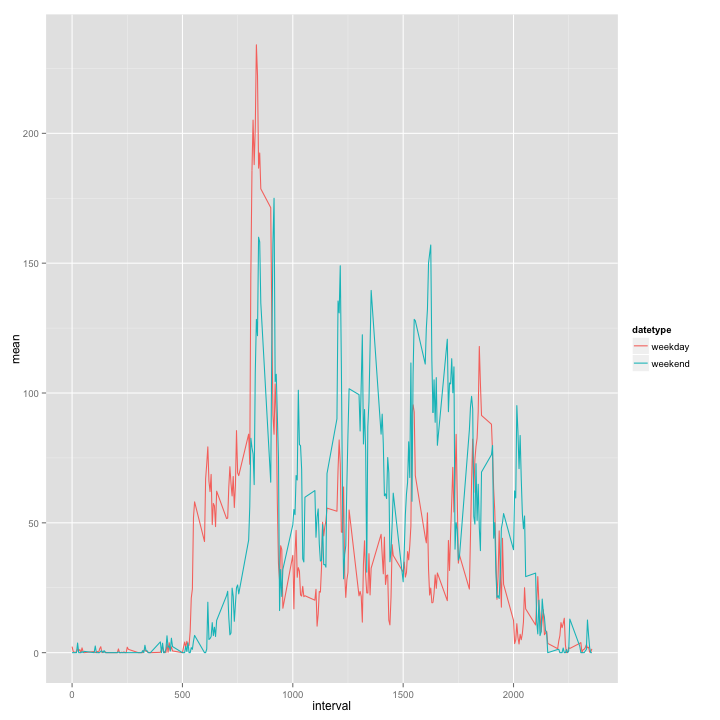

```r
ggplot(agg.data, aes(x = interval, y = mean, col = datetype)) + geom_line(type = "l")
```